# Dog Bark

Ivory Blakley

# High level summary

What do we have in the training set?

```r
csv = read.csv("../input/train.csv", header=T)
head(csv)
```

```
##          fname        label manually_verified
## 1 00044347.wav       Hi-hat                 0
## 2 001ca53d.wav    Saxophone                 1
## 3 002d256b.wav      Trumpet                 0
## 4 0033e230.wav Glockenspiel                 1
## 5 00353774.wav        Cello                 1
## 6 003b91e8.wav        Cello                 0
```

The [description of the data](https://www.kaggle.com/c/freesound-audio-tagging/data) says that *“a number of Freesound audio samples were automatically annotated with labels from the AudioSet Ontology … Then, a data validation process was carried out in which a number of participants did listen to the annotated sounds and manually assessed the presence/absence of an automatically assigned sound category”.* And that *“The non-verified annotations of the train set have a quality estimate of at least 65-70% in each category.”*

With that in mind, I would prefer to use only the manually verified data.

```r
csv = csv[csv$manually_verified == 1,]
head(csv)
```

```
##           fname              label manually_verified
## 2  001ca53d.wav          Saxophone                 1
## 4  0033e230.wav       Glockenspiel                 1
## 5  00353774.wav              Cello                 1
## 7  003da8e5.wav              Knock                 1
## 8  0048fd00.wav Gunshot_or_gunfire                 1
## 11 006f2f32.wav             Hi-hat                 1
```

With that reduction, how many do we have in each category?

```r
labalTable = table(csv$label)
```

There are 67 sound clips labeled “Bark”.

Of course, all of these files are in the inputs folder.

```r
csv$filePath = paste0("../input/audio_train/", csv$fname)
```

Grab all of the sounds of dogs barking.

```r
barkSoundClips = csv$filePath[csv$label=="Bark"]
```

# Example dog bark

```r
library(audio)
b1 = load.wave(barkSoundClips[1])
sample.rate = attr(b1, "rate")
str(b1)
```

```
## Class 'audioSample'  atomic [1:620928] -3.05e-05 3.05e-05 0.00 -3.05e-05 -3.05e-05 ...
##   ..- attr(*, "rate")= int 44100
##   ..- attr(*, "bits")= int 16
```

The “rate” of 44,100 means that the pressure in front of the microphone was measured 44,100 times per second. Thus, the entire clip is 14 seconds long, and has 620,928 values.

```r
play(b1)
```

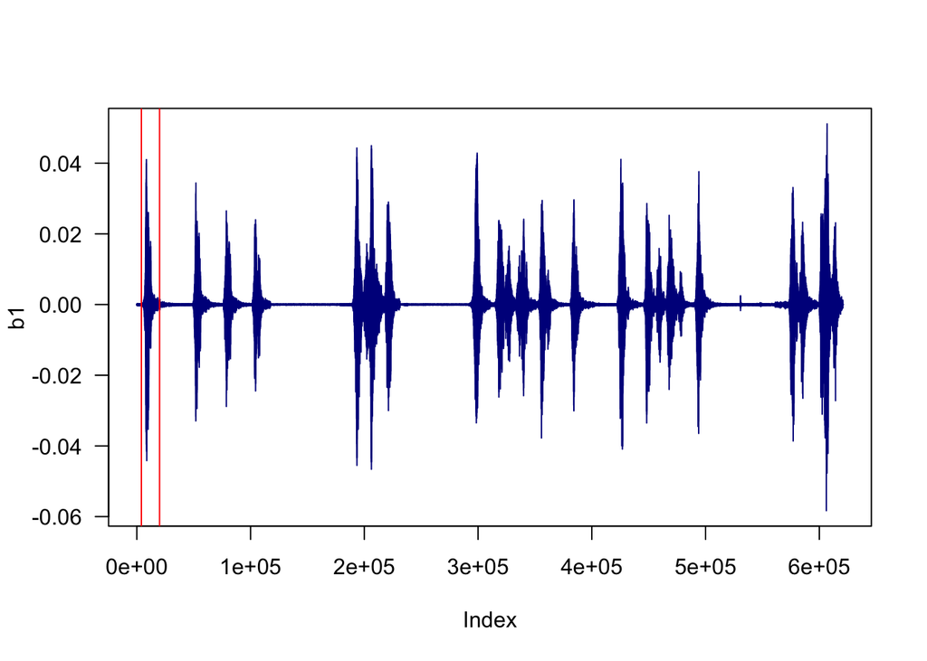

```r
plot(b1, type="l", col="darkblue", las=1)
start=4000
end=20000
abline(v=start, col="red"); abline(v=end, col="red")
```

Zoom in to the range marked by the two red lines.

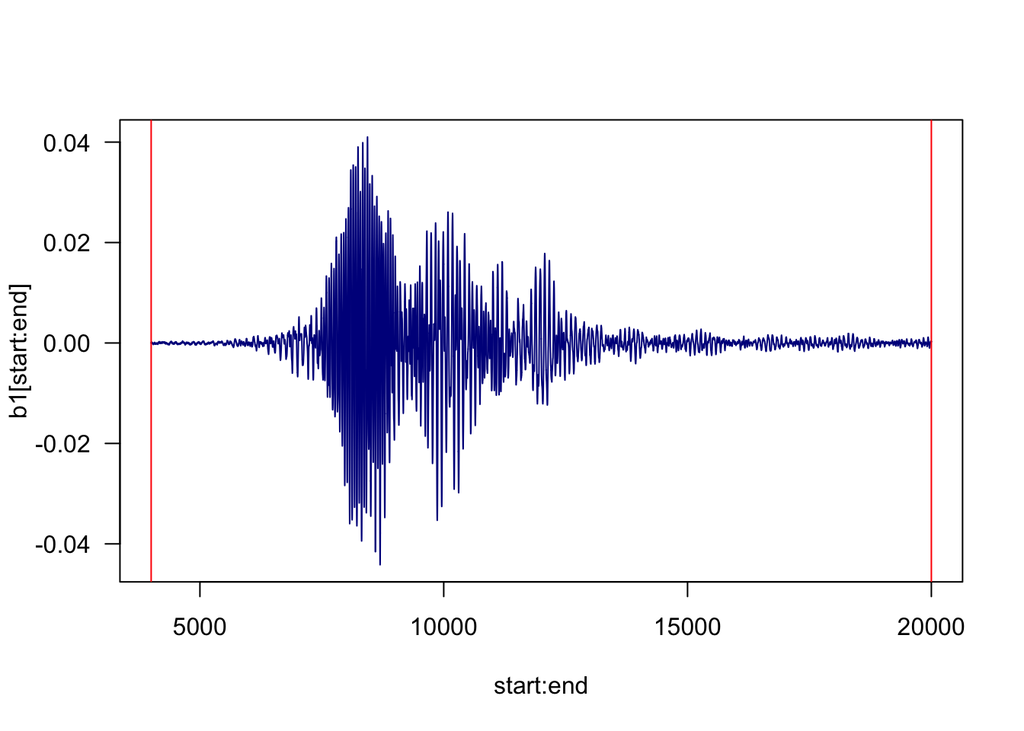

```r
plot(start:end, b1[start:end], type="l", col="darkblue", las=1)
abline(v=start, col="red"); abline(v=end, col="red")
```

```r
play(b1[start:end])
arf = as.numeric(b1[start:end])
```

# Fourier transform

## generic

### Make some waves.

```r
example.rate = 10
x <- seq(-30, 70, by = 1/example.rate)
wav.freq = c(0.8, 1.5, 2)
wav.1 = sin(wav.freq[1] * x)
wav.2 = sin(wav.freq[2] * x)
wav.3 = rep(0, length(x))
xmid = seq(0, 20, by = 1/example.rate)
someMidXs = which(x>0 & x < max(x)/3)
xmid = x[someMidXs]
wav.3[someMidXs] = 1.6 * sin(wav.freq[3] * xmid)
wav.sum = wav.1 + wav.2 + wav.3
waves = list("wave1" = wav.1,
                         "wave2" = wav.2,
                         "wave3" = wav.3,
                         "sum" = wav.sum)
```

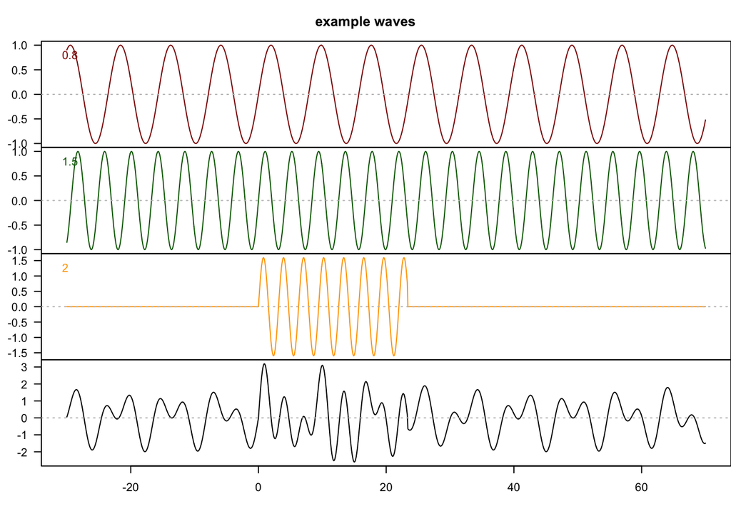

The Forier transfrom is beautifully explained by 3blue1brown in his video [“But what is the Fourier Transform? A visual introduction.”](https://www.youtube.com/watch?v=spUNpyF58BY) I’m using that as my bases for making the following function.

### The fourier transformation

```r
fourtrans = function(f, g, t){
    # f - scaler, the "winding frequency"
    # g - a vector describing the original wave.
    # t - a vector of times corresponding to g; g and t must be the same length
    i = complex(imaginary=1)
    mass = g * exp( -2 * pi * i * f * t)
    return(sum(sum(mass))) # the double sum is diliberate.
}
```

Do the fourier transform on the example waves.

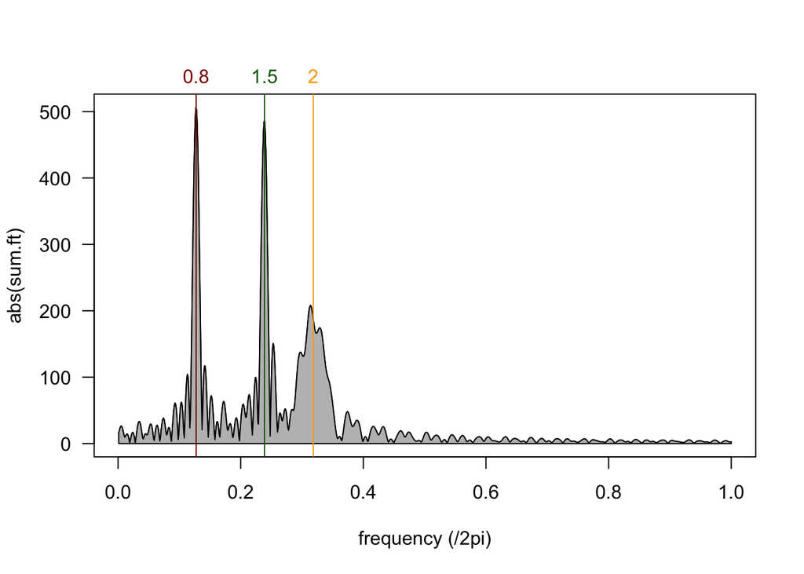

```r
ex.freqs = seq(0.001, 1, 0.001)
sum.ft = sapply(ex.freqs, fourtrans, g=wav.sum, t=x)
plot(ex.freqs, abs(sum.ft), type="l", las=1, xlab="frequency (/2pi)")
polygon(x=c(max(ex.freqs), min(ex.freqs), ex.freqs), c(0,0, abs(sum.ft)), col="gray")
for (i in 1:length(wav.freq)){
    abline(v=wav.freq[i]/(2*pi), col=wav.colors[i])
    text(x=wav.freq[i]/(2*pi), y=par("usr")[4], xpd=T, pos=3, col=wav.colors[i], labels=wav.freq[i])
}
```

I see what I want. I see peaks that corresond to my original frequencies. But how to extract them when I don’t know the values and I don’t know how many there are? If I take every peak, I will have too many.

### Pick out peaks

```r
getMaxima = function(vector){
    n=length(vector)
    left = vector[1:(n-2)]
    main = vector[2:(n-1)]
    right = vector [3:n]
    indecies = which(main > left & main > right)
    return(indecies)
}
rawMaxima = getMaxima(abs(sum.ft))
```

Using the raw values and taking EVERY maximum gives me 73 frequencies.

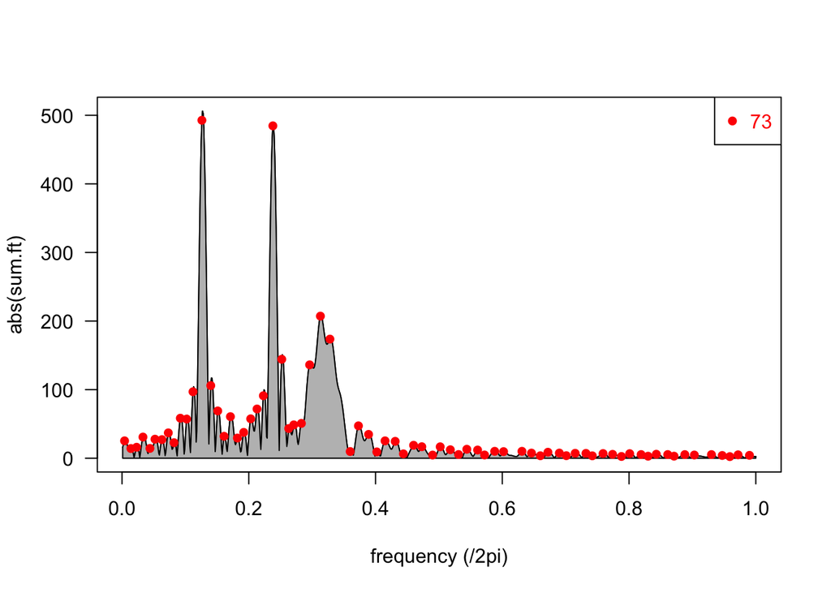

```r
plot(ex.freqs, abs(sum.ft), type="l", las=1, xlab="frequency (/2pi)")
polygon(x=c(max(ex.freqs), min(ex.freqs), ex.freqs), c(0,0, abs(sum.ft)), col="gray")
points(col="red", pch=16, x=ex.freqs[rawMaxima], abs(sum.ft)[rawMaxima])
legend(legend=length(rawMaxima), x="topright", text.col="red", pch=16, col="red")
```

I could order them by their intensity (y-axis), but without knowing how many there are, I might stop with only 2 or take on several too many.

### Optimize smoothing parameter - span

```r
small = quantile(abs(sum.ft)[rawMaxima], .75) * 2
```

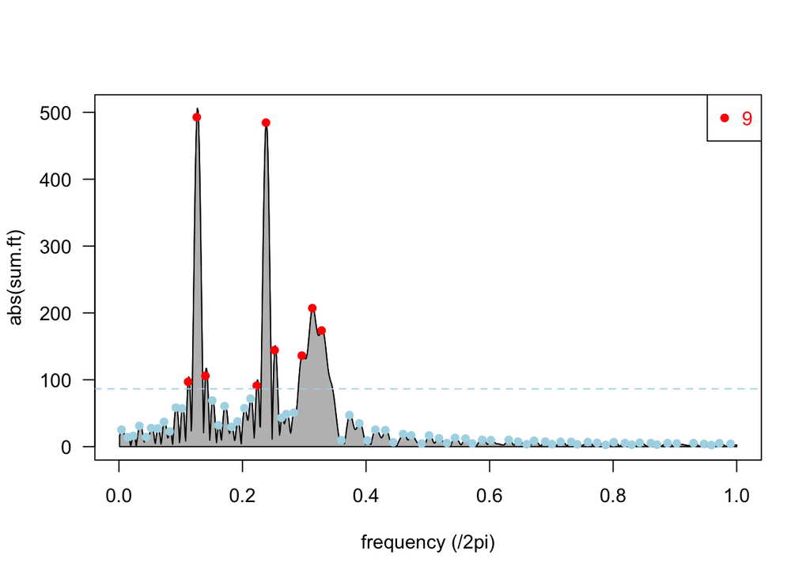

```r
dotColor = rep("red", length(rawMaxima))
dotColor[abs(sum.ft)[rawMaxima] <= small] = "lightblue"

plot(ex.freqs, abs(sum.ft), type="l", las=1, xlab="frequency (/2pi)")
polygon(x=c(max(ex.freqs), min(ex.freqs), ex.freqs), c(0,0, abs(sum.ft)), col="gray")
points(col=dotColor, pch=16, x=ex.freqs[rawMaxima], abs(sum.ft)[rawMaxima])
abline(h=small, lty=2, col="lightblue")
legend(legend=sum(dotColor=="red"), x="topright", text.col="red", pch=16, col="red")
```

Smooth out the values to remove unimportant peaks.

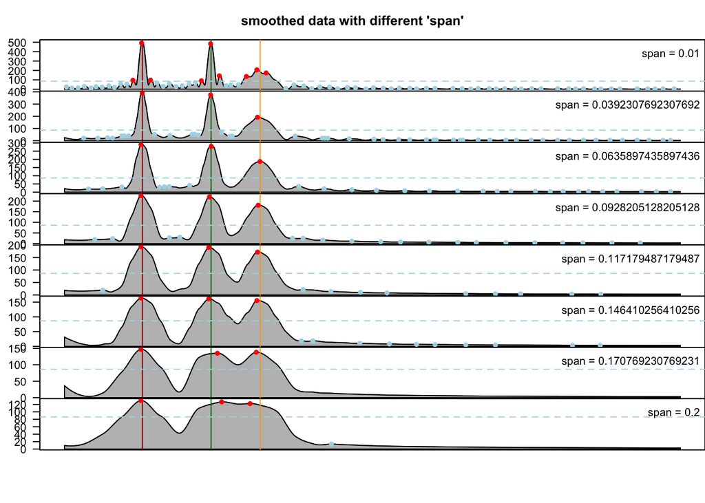

```r
n.panels = 8
par(mfrow=c(n.panels,1), las=1, mar=c(0,3,0,0), oma=c(4,0,3,0))

span = seq(0.01, .2, length.out = 40)
n.span = length(span)
drawThese = round(seq(1, n.span, length.out = n.panels))
drawList = list()
numMaxes = rep(NA, length(span))
for (i in 1:n.span){
    ft.lo = loess(abs(sum.ft) ~ ex.freqs, span=span[i])
    smoother = predict(ft.lo, ex.freqs)
    maxes = getMaxima(smoother)
    numMaxes[i] = sum(smoother[maxes] > small)
    if (i %in% drawThese) {
        plot(ex.freqs, smoother, type="l", las=1, xlab="frequency (/2pi)", xaxt="n")
        polygon(x=c(max(ex.freqs), min(ex.freqs), ex.freqs), c(0,0, smoother), col="gray")
        abline(v=wav.freq/(2*pi), col=wav.colors)
        legend(x="topright", legend=paste("span =", span[i]), bty="n")
        dotCol = rep("red", length(maxes))
        dotCol[smoother[maxes] <= small] = "lightblue"
        abline(h=small, lty=2, col="lightblue")
        points(col=dotCol, pch=16, x=ex.freqs[maxes], smoother[maxes])
    }
}
title("smoothed data with different 'span'", outer = T)
```

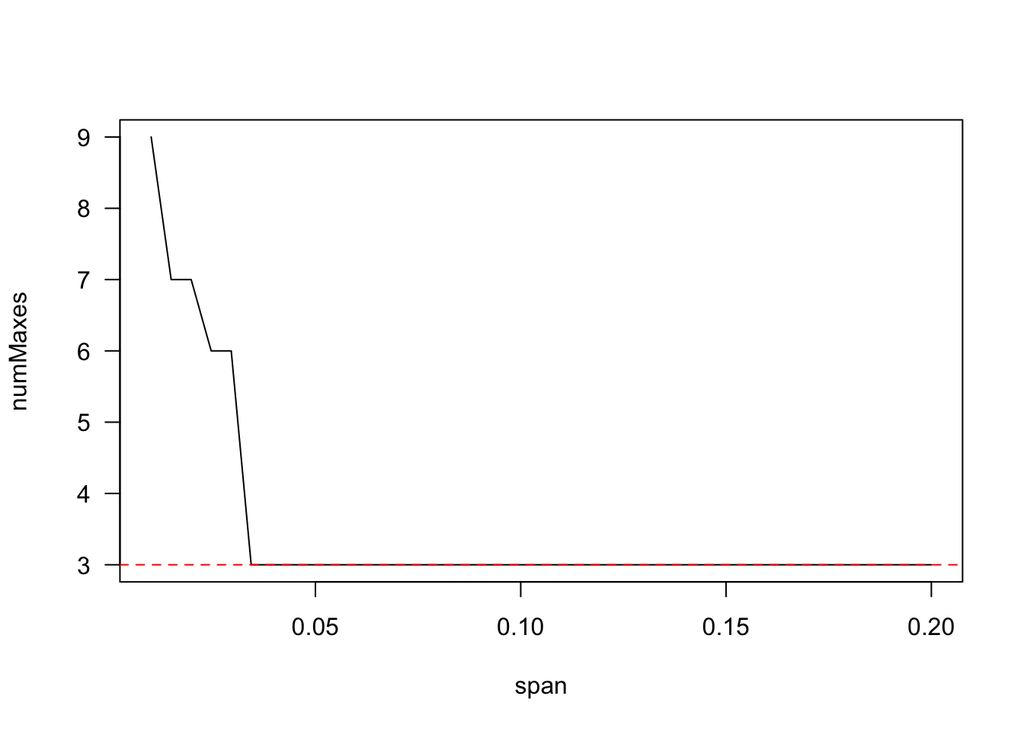

```r
plot(span, numMaxes, type="l", las=1)
abline(h=3, lty=2, col="red")
```

Now we need a rule a computer can follow that will help it come to similar conclusions about optimizing the span for a given clip. There is probably some really good algorithm for doing that, but for now this will do:

```r
# What is the most common number of peaks (across different span parameters)
# That must be right.  What is the lowest span that gives me that many? That must be best.
getBestSpan = function(numMaxes, span){
    tb = table(numMaxes)
    tb = tb[order(tb, decreasing = T)]
    mode = as.numeric(names(tb)[1])
    w = which(numMaxes == mode)
    lowSpan = span[min(w)]
    return(lowSpan)
}
lowSpan = getBestSpan(numMaxes, span)
```

Based on this logic, 0.034 is the optimum span parameter for this clip.

```r
getBestFreqs = function(ft, freqs, lowSpan){
    ft.lo.best = loess(abs(ft) ~ freqs, span=lowSpan)
    smoother = predict(ft.lo.best, freqs)
    maxes = getMaxima(smoother)
    maxes = maxes[smoother[maxes] > small]
    freq.of.interest = freqs[maxes] * 2 * pi
    return(freq.of.interest)
}
freq.of.interest = getBestFreqs(sum.ft, ex.freqs, lowSpan)
```

And based on that value for span, the frequencies of interest are:

```
## [1] 0.7979645 1.4953981 1.9666370
```

### sliding window

The peak for the wave 3 frequency is shorter and wider than the other two. This makes sense since it was only present in a small portion of the clip while the other two were present consitently. Lets apply a sliding window approach.

Define the windows.

```r
winSize = 300 # how may values wide each window is
shift = 10 # how many values from the start of one window to the start of the next
len = length(wav.sum) # how many total values in the clip
winStarts = seq(1, len-winSize, shift)
winEnds = seq(winSize, len, shift)
```

For each window, do the fourier transform and save the value for each frequency.

```r
nw = length(winStarts) # number of windows
ex.freqs = seq(0.001, 1, 0.001)
shiftingFT = matrix(NA, ncol = length(ex.freqs), nrow=nw,
                                        dimnames=list(startTime=x[winStarts], frequency=ex.freqs))
for (i in 1:nw){
    win = wav.sum[winStarts[i]:winEnds[i]]
    shiftingFT[i,] = sapply(ex.freqs, fourtrans, g=win, t=x[winStarts[i]:winEnds[i]])
}
shiftingFT.real = abs(shiftingFT)
```

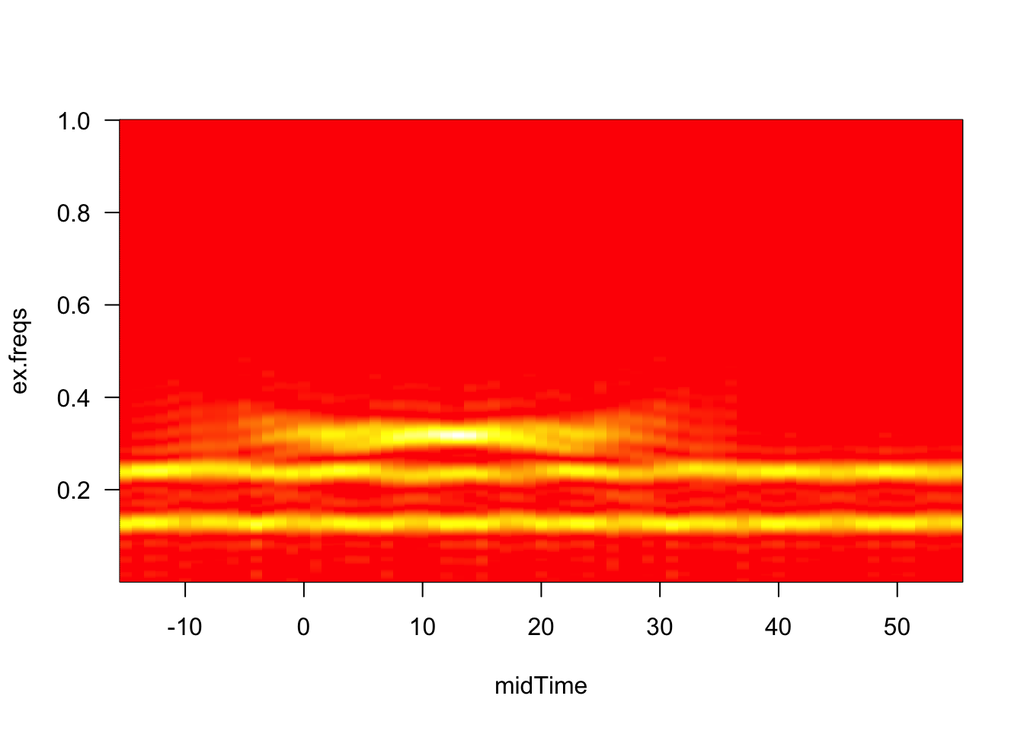

```r
midTime=round((x[winStarts]+x[winEnds])/2)
image(x=midTime, y=ex.freqs, z=shiftingFT.real, las=1, col=heat.colors(length(shiftingFT.real)))
```

For the just the frequences of intersest, plot their intensity over time (across the sliding windows).

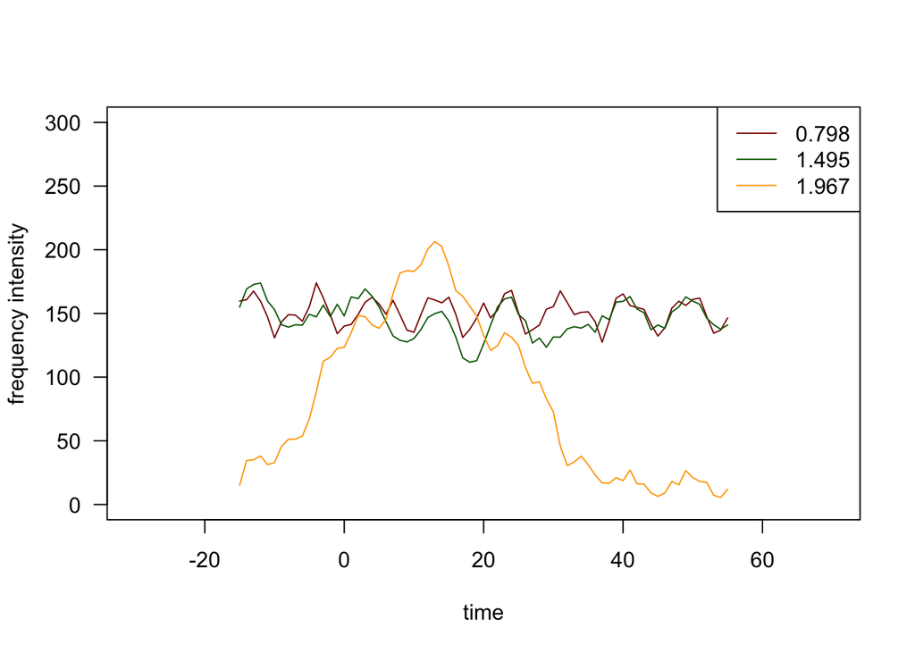

```r
freq.of.interest = freq.of.interest [order(freq.of.interest)] # make sure they are in the original order
plot(1,1, xlim=range(x), ylim=c(0,300), type="n",
         xlab="time", ylab="frequency intensity", las=1)
for (i in 1:3){
    fq = as.character(freq.of.interest[i] / (2 * pi))
    lines(x=midTime, y=shiftingFT.real[,fq], col=wav.colors[i])
}
legend(x="topright", legend = round(freq.of.interest,3), col=wav.colors, lty=1)
```

The only thing we did to optimize the window size and shift size was… well nothing. I looked at the picture and adjusted it. I don’t know any good rules there, except hope that the same parameters work well over most cases.

## dog bark

The original wave (g) is represented by our input data. For t, we need to create a vector of time measurements corresponding to the values in our sound clip.

```r
getTimes = function(clipVals, rate=sample.rate){
    #clipVals - a vector representing a sound clip.
    # value => a vector representing the time measurements for those values
    indecies = 1:length(clipVals)
    return(indecies/rate)
}
times = getTimes(arf)
```

Based on Wikipedia’s [Audio Frequency](https://en.wikipedia.org/wiki/Audio_frequency) page, sound frequencies that we can hear will be covered by a range of about 20 to 20,000 Hz.

```r
freq = seq(20, 20000, 100)
```

Do the Fourier Transform for the arf sample.

```r
arf.ft = sapply(freq, fourtrans, g=arf, t=times)
arfMaxes = getMaxima(abs(arf.ft))
```

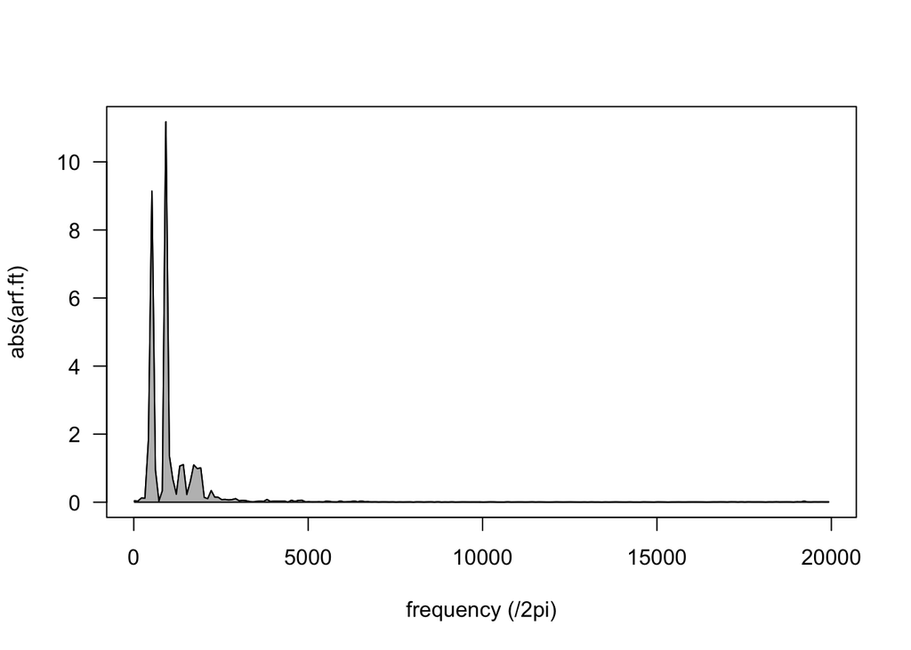

```r
plot(freq, abs(arf.ft), type="l", las=1, xlab="frequency (/2pi)")
polygon(x=c(max(freq), min(freq), freq), c(0,0, abs(arf.ft)), col="gray")
```

```r
#points(col="red", pch=16, x=freq[arfMaxes], y=abs(arf.ft)[arfMaxes])
```